# R Notebook

1. Illustration of mean and standard deviation.
1. Compute the mean and the standard deviation for 1, 1.5, 2, 2.5, 3.
2. Compute the mean and the standard deviation for 1, 1.5, 2, 2.5, 30.
3. Comment on the differences.

```r
x1_sd
```

```
[1] 0.7905694
```

2. Comparing normality for two genes. Consider the gene expression val- ues in row 790 and 66 of the Golub et al. (1999) data.
1. Produce a boxplot for the expression values of the ALL patients and comment on the differences. Are there outliers? For line 790 there are 3 outliers, for line 66 there are none
2. Produce a QQ-plot and formulate a hypothesis about the normal- ity of the genes.

66 is normally distributed, but 790 is not

3. Compute the mean and the median for the expression values of the ALL patients and compare these. Do this for both genes. Due to outliers on right hand side mean -1.17 is larger than -1.28. For gen in row 66 the mean is 1.182503 and the median is 1.23023 the differences are smaller.

```r
library(ALL)
data(golub, package = "multtest")
i<-c(66,790)
#a) ====
data_snippet_790<-golub[790,]
data_snippet_66<- golub[66,]
gol.fac <- factor(golub.cl,levels=0:1, labels= c("ALL","AML"))
boxplot(golub[790,],gol.fac=="ALL")
boxplot(golub[66,],gol.fac=="ALL")
boxplot(golub[790,]~gol.fac)
boxplot(golub[66,]~gol.fac)
#b)====
qqnorm(golub[790, gol.fac=="ALL"])
qqline(golub[790, gol.fac=="ALL"])
qqnorm(golub[66, gol.fac=="ALL"])
qqline(golub[66, gol.fac=="ALL"])

#c)====
ds_mean_66<-mean(golub[66,gol.fac=="ALL"])
ds_mean_790<-mean(golub[790,gol.fac=="ALL"])
ds_median_66<-median(golub[66,gol.fac=="ALL"])
ds_median_790<-median(golub[790,gol.fac=="ALL"])
```

[output not shown]

3. Effect size. An important statistic to measure the effect size which is defined for a sample as x/s. It measures the mean relative to the standard deviation, so that is value is large when the mean is large and the standard deviation small.
1. Determine the five genes with the largest effect size of the ALL patients from the Golub et al. (1999) data. Comment on their size.
1. Compute factor mean/sd for all golub ALL, sort and grep top5, get size of thosee genes Mean with 11x larger than sd is large=?
2. Invent a robust variant of the effect size and use it to answer the previous question.

```r
#a)====
gol.fac <-factor(golub.cl,levels=0:1,labels=c("ALL","AML"))
golub_es<- apply(golub[,gol.fac=="ALL"], 1, mean)/apply(golub[,gol.fac=="ALL"], 1, sd)
golub_es_2 <- apply(golub[,gol.fac=="ALL"],1,function(x)mean(x)/sd(x))
#golub_es == golub_es_2

o <- order(golub_es, decreasing = TRUE)
golub_es[o[1:5]]

golub.gnames[o[1:5],2]

#b====
#define median by MAD OR divide median by IQR
#mad equals sd if bellshaped normally distributed
golub_es_robust <- apply(golub[,gol.fac=="ALL"],1,function(x)mean(x)/mad(x))
#plot with quantile plotting ?
o<- order(golub_es_robust,decreasing = TRUE)
golub_es_robust[o[1:5]]
golub.gnames[o[1:5],2]

golub_es_robust_IQR <- apply(golub[,gol.fac=="ALL"],1, function(x)median(x)/IQR(x))
o<- order(golub_es_robust_IQR,decreasing = TRUE)
golub_es_robust_IQR[o[1:5]]
golub.gnames[o[1:5],2]

qqnorm(golub_es_robust)
qqline(golub_es_robust)

qqnorm(golub_es_robust_IQR)
qqline(golub_es_robust_IQR)
```

[output not shown]

4. Plotting gene expressions “CCND3 Cyclin D3”. Use the gene expres- sions from “CCND3 Cyclin D3” of Golub et al. (1999) collected in row 1042 of the object golub from the multtest library. After using the function plot you produce an object on which you can program.
1. Produce a so-called stripchart for the gene expressions separately for the ALL as well as for the AML patients. Hint: Use a factor for appropriate separation.
2. Rotate the plot to a vertical position and keep it that way for the questions to come.
3. Color the ALL expressions red and AML blue. Hint: Use the col parameter.
4. Add a title to the plot. Hint: Use title.
5. Change the boxes into stars. Hint: Use the pch parameter. Hint: Store the final script you like the most in your typewriter in order to be able to use it efficiently later on.

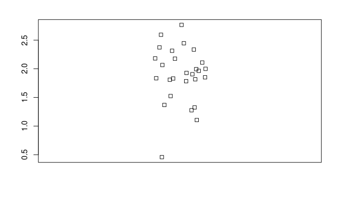

```r
#a)====
gol.fac <-factor(golub.cl,levels=0:1,labels=c("ALL","AML"))

stripchart(golub[1042, gol.fac=="ALL"], method="jitter",vertical = TRUE)
```

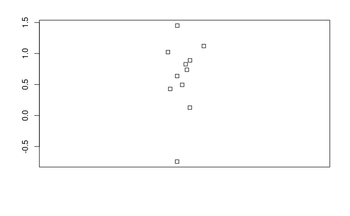

```r
stripchart(golub[1042, gol.fac=="AML"], method="jitter", vertical=TRUE)
```

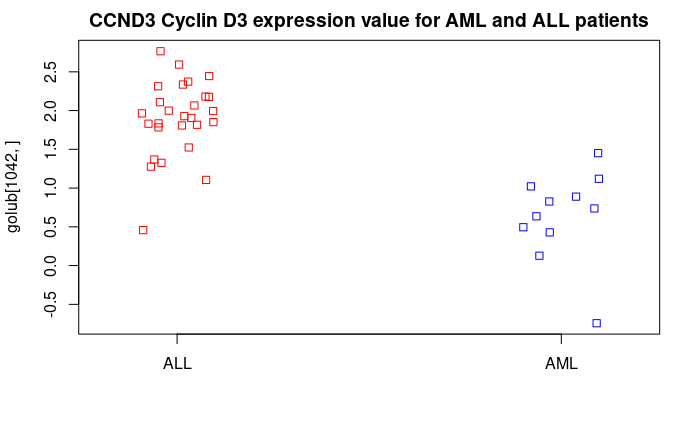

```r
stripchart(golub[1042,] ~ gol.fac,method="jitter",col=c("red", "blue"),vertical = TRUE)
title("CCND3 Cyclin D3 expression value for AML and ALL patients")
```

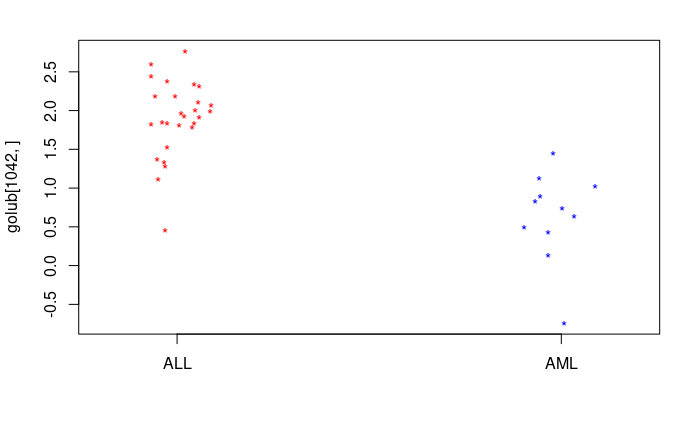

```r
stripchart(golub[1042,] ~ gol.fac,method="jitter",col=c("red", "blue"),pch="*",vertical = TRUE)
```

5. Box-and-Whiskers plot of “CCND3 Cyclin D3”. Use the gene expres- sions “CCND3 Cyclin D3” of Golub et al. (1999) from row 1042 of the object golub of the multtest library.
1. Construct the boxplot in Figure 2.6.
2. Add text to the plot to explain the meaning of the upper and lower part of the box.
3. Do the same for the wiskers.
4. Export your plot to eps format. Hint locator() to find coordinates of the position of the plot. xlim to make the plot somewhat wider. arrows to add an arrow. text to add information at a certain position.

```r
gol.fac <-factor(golub.cl,levels=0:1,labels=c("ALL","AML"))
z<-boxplot(golub[1042,] ~gol.fac)
locator(boxplot(golub[1042,]~gol.fac))
x11()
x<-data(golub, package = "multtest")
#PROBLEM: plot.new has not been called yet - der Plot muss zusammen in einem run erzeugt werden
#Außerdem läuft dann locator() im loop und das programm nicht weiter?
boxplot(x,xlim=c(0,4))
#arrows(2.0,1.93,1.24,1.93);text(2.5,1.93,"Median")
#arrows(2.0,1.1,1.24,1.1) ;text(2.5,1.1,"Outlier")
#arrows(2.0,1.79,1.24,1.79);text(2.5,1.79,"first quartile")
#arrows(2.0,2.17,1.24,2.17);text(2.5,2.17,"third quartile")
#arrows(2.0,1.27,1.24,1.27);text(2.5,1.27,"lower wisker")
#arrows(2.0,2.59,1.24,2.59);text(2.5,2.59,"upper wisker")
#dev.copy2eps(device=x11,file="BoxplotWithExplanation.eps")
#boxplot.stats(x, coef = 1.5, do.conf = TRUE, do.out = TRUE)
```

[output not shown]

6. Box-and-wiskers plot of persons of Golub et al. (1999) data.
1. Use boxplot(data.frame(golub)) to produce a box-and-wiskers plot for each column (person). Make a screen shot to save it in a word processor. Describe what you see. Are the medians of similar size? Is the inter quartile range more or less equal. Are there outliers?

Medians are all around zero. Interquartile Range differs just slightly, the minimal values are all around minus 1.5, all persons have outliers near to 3

2. Compute the mean and medians of the persons. What do you observe?
3. Compute the range (minimal and maximum value) of the standard deviations, the IQR and MAD of the persons. Comment of what you observe.

```r
library(ALL)
data(golub, package = "multtest")
#a)====
golub_persons <- data.frame(golub)
boxplot(golub_persons)
#b)====
median_persons<- apply(golub_persons,2, median)
mean_persons<- apply(golub_persons,2, mean)
median_persons
mean_persons
#c)====
range(apply(golub_persons,2,sd))
#Daran denken, dass IQR *(Interquartile Range IQ = UPPER QUARTILE - LOWER QUARTILE) is approximately 1.349 times the standard deviation
range(apply(golub_persons, 2, function(x)IQR(x)/1.349))
range(apply(golub_persons, 2, mad))
```

[output not shown]

7. Oncogenes of Golub et al. (1999) data.
1. Select the oncogens by the grep facility and produce a box-and- wiskers plot of the gene expressions of the ALL patients.
2. Do the same for the AML patients and use par(mfrow=c(2,1)) to combine the two plots such that the second is beneath the first. Are there genes with clear differences between the groups?

Yes.

Musterloesung: The plot gives a nice overview of the distributions of the gene expressions values of the onco gene separately for the ALL and the AML patients. Several genes behave similarly for ALL and AML. Some are clearly distributed around zero, but others not. Also, some have a small inter quartile ranges, while for others this is large. A similar statement holds for outliers, some do not have outliers, but others certainly have. Some gene show distinct distributions between patient groups. For instance, the sixth has ALL expressions around zero, but those for AML are larger than zero.

```r
#a)==== Musterloesung ====
data(golub, package="multtest")
gol.fac <- factor(golub.cl,levels=0:1, labels= c("ALL","AML"))
rowindex <- agrep("^oncogene",golub.gnames[,2])
length(rowindex)

oncogol <- golub[rowindex,]
oncogolub.gnames <- golub.gnames[rowindex,]
row.names(oncogol) <- oncogolub.gnames[,3]
#t to transpose matrix because columns and lines are distorted? I dont get it .
#par command to choose a layout of how the plots will be displayed
par(mfrow=c(2,1))

boxplot(data.frame(t(oncogol[,gol.fac=="ALL"])))
title("Box and whiskers plot for oncogenes of ALL patients")
#b)====

boxplot(data.frame(t(oncogol[,gol.fac=="AML"])))
title("Box and whiskers plot for oncogenes of AML patients")
```

[output not shown]

8. Descriptive statistics for the ALL gene expression values of the Golub et al. (1999) data.
1. Compute the mean and median for gene expression values of the ALL patients, report their range and comment on it.

My Answer: The range of both varies highly, the mean:

[1] -1.330984 3.278551

The median:

[1] -1.36832 3.35455

But mean and median show similarities in range towards another, which indicates a symmetric distribution of data

2. Compute the SD, IQR, and MAD for gene expression values of the ALL patients, report their range and comment on it.

low standard deviation implicates values tend to be close to mean, high that values are very further spread Here the sd varies alot between datasets

IQR The interquartile Range shows the “mid fifty” from end of quartile 1 to start of quartile 4 (IQR = Q3-Q1). The quartiles seperate the data into bulks such that 1/4 of the values is in Quartile 1,2,3 and 4 respectively. Q1 is the median of lower half, Q3 is median of upper half This indicates that 25% are below low limit, 50% in between and 25% above limit

MAD

```r
library(dplyr)
#a)====
data(golub, package="multtest")
gol.fac <- factor(golub.cl,levels=0:1, labels= c("ALL","AML"))
all_mean <- apply(golub[,gol.fac=="ALL"],1,mean)
all_median <- apply(golub[,gol.fac=="ALL"],1,median)
all_mean
all_median
range(all_mean)
range(all_median)

par(mfrow=c(2,2))

stripchart(all_mean, method="jitter")
title("stripchart of all_mean")
stripchart(all_median, method="jitter")
title("stripchart of all_median")
hist(all_mean)
hist(all_median)

#b)====

all_sd<-apply(golub[,gol.fac=="ALL"],1, sd)
sprintf("standard deviation min: %s standard deviation max: %s" , range(all_sd)[1], range(all_sd)[2])

all_iqr<-apply(golub[,gol.fac=="ALL"],1, IQR)
range(all_iqr)
all_mad<-apply(golub[,gol.fac=="ALL"],1, mad)
range(all_mad)
```

[output not shown]